# Model Selection and Results

Jun Ming Li, Thasin Wahid, Rajivini Tiruveedhula

2024-10-03

Heart Disease is still one of the leading causes of death in Georgia and will remain a problem going forward. What makes heart disease a major issue is that there is not one single factor or specific group of factors that lead to someone developing CVD. Thus, we need to examine heart disease through a statistical lens on health, financial, and socio-economic factors.

Our dependent variable, prevalence of cardiovascular disease, is our variable of study. Our independent variables are Smoking, Unemployment, Education, Air Pollution, Housing Problems, Obesity, and Physical Inactivity. These were all included in our model because of their evidence of link to prevalence of heart disease and to use factors that may be believed to have an effect but might not impact heart disease as one might believe. In a study done by [Wenjie Sun, et. al](https://link.springer.com/article/10.1007/s10708-019-10049-7), they determined education, unemployment, and environment were all important factors for predicting prevalence of CHD. Similarly, health factors such as smoking, obesity, and physical inactivity all being highly correlated with risk of heart disease [(Fiscella and Tancredi)](https://www.ncbi.nlm.nih.gov/pmc/articles/PMC2684464/).

# Data and Methods

The variables chosen for this study were median household income, unemployment rate, education (HS diploma) rate, diabetes prevalence, smoker rate, air pollution, housing problems, obesity rate, alcohol abuse rate, insufficient sleep, water violations, and physical inactivity. The data was gathered at the county level and are measures of the proportion of individuals from the county as a whole who fit the criteria of the variable. The variables chosen were consistent with prior studies by Sun et.al. and Fiscella et. al.

## Data Dictionary

- **CHD_Prev**: Coronary Heart Disease prevalence is based on a percentage of the population that has been diagnosed with coronary heart disease at a given time; typically measured annually and is calculated using health surveys, medical records, or public health registries.
- **MedianIncome**: Average Median Household Income in a county.
- **Umemploy**: Unemployment Rate in % of population.
- **Smoker**: Percentage of adults who are current smokers within the given county.
- **Education**: Adults age 25 and over with a high school diploma or equivalent.
- **Diabetes**: Proportion of the population in the specific county that has been diagnosed with diabetes at any period of time, typically measured annually.
- **Alcohol**: Percentage of all adults within a county that drink excessively as defined by the health data website as drinking 5 or more alcoholic beverages a day or 15 a week.
- **Obesity**: Percentage of adults that report BMI >= 30 within the given county.
- **AirPollution**: Average daily amount of fine particulate matter in micrograms per cubic meter.
- **Physical**: Percentage of adults age 18 and over reporting no leisure-time physical activity (age-adjusted).
- **Insleep**: Percentage of adults who report fewer than 7 hours of sleep on average (age-adjusted).
- **waterVio**: Indicator of the presence of health-related drinking water violations. ‘Yes’ indicates the presence of a violation, ‘No’ indicates no violation.
- **HousingProb**: Percentage of households with at least 1 of 4 housing problems: overcrowding, high housing costs, lack of kitchen facilities, or lack of plumbing facilities.

The model that was ultimately chosen uses unemployment rate, smoker rate, education (HS diploma) rate, air pollution, housing problems, obesity rate, and lack of leisure time for physical inactivity to explain CHD prevalence in the counties of Georgia. Our initial approach was to use all our variables in the regression model, but there were issues with multicollinearity, outliers and high-leverage points, and fitting. To increase the fit of our model and reduce the effects of bias and confounding variables, the model was refined through a multi-step process. The initial regression of CHD prevalence with all the predictor variables was scanned for outliers and those points were removed. These points were chosen after reviewing the residual plots. Upon closer inspection, those counties were removed because they had values beyond +/- 2 standard deviations from the mean on multiple variables.

$$lm(CHD_Prev \sim\
Unemploy+Smoker*Education + AirPollution + HousingProb +
Obesity*Physical)$$

```
## 'data.frame':    158 obs. of  15 variables:
##  $ County      : chr  "Appling" "Atkinson" "Bacon" "Baker" ...
##  $ Population  : int  18386 8165 11164 3038 44890 19234 83240 107738 16700 19397 ...
##  $ CHD_Prev    : num  7.4 8.6 8 10.3 6.9 7.7 5.6 6.3 8.6 8.4 ...
##  $ MedIncome   : int  43821 38581 41807 39515 44429 53481 68924 60254 35931 42058 ...
##  $ Education   : int  75 67 82 81 86 76 85 84 84 79 ...
##  $ Unemploy    : num  3.9 3 3.5 4.7 4.2 2.7 2.8 3.3 5.5 4 ...
##  $ Diabetes    : int  17 13 13 18 12 9 14 9 21 12 ...
##  $ Obesity     : int  34 31 44 36 41 33 39 29 42 37 ...
##  $ Alcohol     : int  16 15 16 16 16 18 17 17 14 16 ...
##  $ Physical    : int  41 30 38 26 26 36 23 30 41 29 ...
##  $ Insleep     : int  41 39 40 42 42 39 39 38 41 40 ...
##  $ Smoker      : int  25 26 25 22 23 23 20 21 24 25 ...
##  $ AirPollution: num  9.4 9.4 9.2 9.5 10.2 10 10.5 10.4 9.3 9.7 ...
##  $ WaterVio    : chr  "No" "No" "No" "No" ...
##  $ HousingProb : int  12 13 12 14 20 14 13 15 16 13 ...
```

```
##
## Call:
## lm(formula = CHD_Prev ~ . - County - Population, data = CHDfull)
##
## Residuals:
##     Min      1Q  Median      3Q     Max
## -2.3563 -0.7332  0.0883  0.6470  3.7684
##
## Coefficients:
##                Estimate Std. Error t value Pr(>|t|)
## (Intercept)   8.850e+00  5.308e+00   1.667   0.0976 .
## MedIncome     1.021e-05  1.634e-05   0.625   0.5329
## Education    -9.819e-03  2.678e-02  -0.367   0.7144
## Unemploy     -2.894e-01  1.296e-01  -2.234   0.0270 *
## Diabetes      1.510e-02  2.349e-02   0.643   0.5212
## Obesity       4.981e-03  1.606e-02   0.310   0.7569
## Alcohol      -7.187e-02  9.857e-02  -0.729   0.4671
## Physical     -1.866e-02  1.885e-02  -0.990   0.3237
## Insleep      -1.466e-02  6.731e-02  -0.218   0.8279
## Smoker        1.808e-01  7.974e-02   2.267   0.0249 *
## AirPollution -2.305e-01  1.407e-01  -1.638   0.1036
## WaterVioYes  -1.812e-01  2.342e-01  -0.774   0.4404
## HousingProb  -3.952e-02  3.956e-02  -0.999   0.3195
## ---
## Signif. codes:  0 '***' 0.001 '**' 0.01 '*' 0.05 '.' 0.1 ' ' 1
##
## Residual standard error: 1.13 on 145 degrees of freedom
## Multiple R-squared:  0.1862, Adjusted R-squared:  0.1188
## F-statistic: 2.764 on 12 and 145 DF,  p-value: 0.002056
```

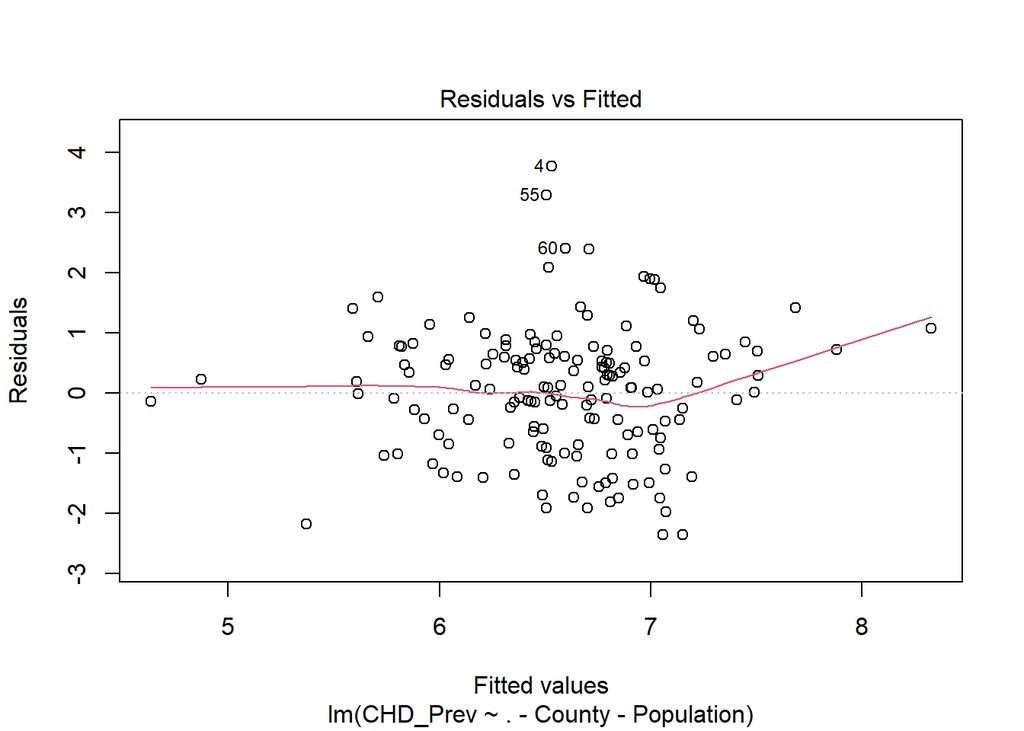

Looking at the correlation of the predictors to each other, we saw high correlations among them. In particular, it was noticed that insufficient sleep, median household income, alcohol, and smoking status had high rates of correlation to many of the other variables. This was also inline with the VIF of each of the variables. To address the multicollinearity issues, the variables insufficient sleep, median household income, and smoking status were removed. When re-running the VIF analysis, each of the remaining variables had a VIF of 1, with alcohol being at 2.1.The remaining variables were run in another regression and the model was put through step-wise analysis to determine a model with the best fit. The analysis excluded the water violations, physical inactivity, and diabetes prevalence.

```
##                   CHD_Prev  MedIncome   Education     Unemploy    Diabetes
## CHD_Prev      1.000000e+00 -0.2480386 -0.30386143  0.009949602  0.11913463
## MedIncome    -2.480386e-01  1.0000000  0.68204081 -0.578994128 -0.37335538
## Education    -3.038614e-01  0.6820408  1.00000000 -0.401041246 -0.25323511
## Unemploy      9.949602e-03 -0.5789941 -0.40104125  1.000000000  0.34151941
## Diabetes      1.191346e-01 -0.3733554 -0.25323511  0.341519405  1.00000000
## Obesity       1.946575e-01 -0.2147146 -0.07131188  0.106482597  0.16373614
## Alcohol      -2.087895e-01  0.6568440  0.48906868 -0.517478524 -0.34438110
## Physical      1.191323e-01 -0.4372221 -0.32437951  0.262037481  0.24626782
## Insleep       1.650199e-01 -0.6967632 -0.44191004  0.601149438  0.35833737
## Smoker        3.719945e-01 -0.8637503 -0.79439225  0.530436229  0.33994023
## AirPollution -1.262289e-01  0.2544271  0.11463194 -0.070286966  0.04983306
## HousingProb   5.756175e-05 -0.3740452 -0.18670990  0.121739658  0.02387169
##                  Obesity     Alcohol    Physical     Insleep     Smoker
## CHD_Prev      0.19465750 -0.20878954  0.11913234  0.16501994  0.3719945
## MedIncome    -0.21471455  0.65684397 -0.43722212 -0.69676317 -0.8637503
## Education    -0.07131188  0.48906868 -0.32437951 -0.44191004 -0.7943923
## Unemploy      0.10648260 -0.51747852  0.26203748  0.60114944  0.5304362
## Diabetes      0.16373614 -0.34438110  0.24626782  0.35833737  0.3399402
## Obesity       1.00000000 -0.32295048  0.26718765  0.22831827  0.2361321
## Alcohol      -0.32295048  1.00000000 -0.35945255 -0.81927721 -0.5985963
## Physical      0.26718765 -0.35945255  1.00000000  0.34810835  0.4447106
## Insleep       0.22831827 -0.81927721  0.34810835  1.00000000  0.6220050
## Smoker        0.23613205 -0.59859631  0.44471061  0.62200504  1.0000000
## AirPollution -0.03124840  0.03899575 -0.03294207 -0.03930252 -0.1487228
## HousingProb   0.13436692 -0.40362819  0.02949889  0.40530500  0.1418207
##              AirPollution   HousingProb
## CHD_Prev      -0.12622891  5.756175e-05
## MedIncome      0.25442714 -3.740452e-01
## Education      0.11463194 -1.867099e-01
## Unemploy      -0.07028697  1.217397e-01
## Diabetes       0.04983306  2.387169e-02
## Obesity       -0.03124840  1.343669e-01
## Alcohol        0.03899575 -4.036282e-01
## Physical      -0.03294207  2.949889e-02
## Insleep       -0.03930252  4.053050e-01
## Smoker        -0.14872283  1.418207e-01
## AirPollution   1.00000000 -7.034960e-02
## HousingProb   -0.07034960  1.000000e+00
```

```
##    MedIncome    Education     Unemploy     Diabetes      Obesity      Alcohol
##     6.419341     3.091410     1.796097     1.286290     1.271389     3.552242
##     Physical      Insleep       Smoker AirPollution     WaterVio  HousingProb
##     1.365810     4.112316     7.582236     1.168645     1.071157     1.712755
```

```
##
## Call:
## lm(formula = CHD_Prev ~ . - County - Population, data = CHDfull_2)
##
## Residuals:
##     Min      1Q  Median      3Q     Max
## -2.1888 -0.7928  0.1197  0.6161  2.7532
##
## Coefficients:
##               Estimate Std. Error t value Pr(>|t|)
## (Intercept)  15.280271   2.513792   6.079 1.05e-08 ***
## Education    -0.057771   0.017055  -3.387 0.000912 ***
## Unemploy     -0.246268   0.108732  -2.265 0.025021 *
## Diabetes      0.012462   0.021219   0.587 0.557912
## Obesity       0.027553   0.014610   1.886 0.061342 .
## Alcohol      -0.099258   0.070797  -1.402 0.163080
## Physical     -0.007642   0.016765  -0.456 0.649189
## AirPollution -0.165048   0.122242  -1.350 0.179094
## WaterVioYes  -0.053573   0.212992  -0.252 0.801767
## HousingProb  -0.045280   0.031116  -1.455 0.147800
## ---
## Signif. codes:  0 '***' 0.001 '**' 0.01 '*' 0.05 '.' 0.1 ' ' 1
##
## Residual standard error: 1.028 on 143 degrees of freedom
## Multiple R-squared:  0.1718, Adjusted R-squared:  0.1197
## F-statistic: 3.296 on 9 and 143 DF,  p-value: 0.00111
```

```
##    Education     Unemploy     Diabetes      Obesity      Alcohol     Physical
##     1.453819     1.507012     1.231975     1.199880     2.136727     1.281285
## AirPollution     WaterVio  HousingProb
##     1.040337     1.060178     1.250966
```

```
##
##
##                             Stepwise Summary
## ----------------------------------------------------------------------
## Step    Variable        AIC        SBC      SBIC      R2       Adj. R2
## ----------------------------------------------------------------------
##  0      Full Model    454.441    487.776      NA    0.17182    0.11970
##  1      WaterVio      452.509    482.813      NA    0.17145    0.12542
##  2      Physical      450.713    477.987      NA    0.17035    0.13030
##  3      Diabetes      449.046    473.290      NA    0.16854    0.13437
## ----------------------------------------------------------------------
##
## Final Model Output
## ------------------
##
##                          Model Summary
## ---------------------------------------------------------------
## R                       0.411       RMSE                 0.996
## R-Squared               0.169       MSE                  1.040
## Adj. R-Squared          0.134       Coef. Var           15.556
## Pred R-Squared          0.090       AIC                449.046
## MAE                     0.810       SBC                473.290
## ---------------------------------------------------------------
##  RMSE: Root Mean Square Error
##  MSE: Mean Square Error
##  MAE: Mean Absolute Error
##  AIC: Akaike Information Criteria
##  SBC: Schwarz Bayesian Criteria
##
##                                ANOVA
## -------------------------------------------------------------------
##                Sum of
##               Squares         DF    Mean Square      F        Sig.
## -------------------------------------------------------------------
## Regression     30.781          6          5.130    4.932     1e-04
## Residual      151.855        146          1.040
## Total         182.637        152
## -------------------------------------------------------------------
##
##                                    Parameter Estimates
## -----------------------------------------------------------------------------------------
##        model      Beta    Std. Error    Std. Beta      t        Sig      lower     upper
## -----------------------------------------------------------------------------------------
##  (Intercept)    15.184         2.294                  6.619    0.000    10.650    19.719
##    Education    -0.057         0.017       -0.308    -3.458    0.001    -0.090    -0.025
##     Unemploy    -0.239         0.106       -0.205    -2.261    0.025    -0.448    -0.030
##      Obesity     0.027         0.014        0.156     1.946    0.054     0.000     0.055
##      Alcohol    -0.102         0.068       -0.160    -1.495    0.137    -0.237     0.033
## AirPollution    -0.162         0.120       -0.103    -1.351    0.179    -0.400     0.075
##  HousingProb    -0.046         0.030       -0.126    -1.509    0.134    -0.106     0.014
## -----------------------------------------------------------------------------------------
```

```
##
## Call:
## lm(formula = CHD_Prev ~ . - County - Population - WaterVio -
##     Physical - Diabetes, data = CHDfull_2)
##
## Residuals:
##     Min      1Q  Median      3Q     Max
## -2.0793 -0.7591  0.1254  0.6943  2.7509
##
## Coefficients:
##              Estimate Std. Error t value Pr(>|t|)
## (Intercept)  15.18444    2.29419   6.619 6.44e-10 ***
## Education    -0.05728    0.01656  -3.458 0.000713 ***
## Unemploy     -0.23892    0.10565  -2.261 0.025208 *
## Obesity       0.02741    0.01408   1.946 0.053560 .
## Alcohol      -0.10210    0.06827  -1.495 0.136956
## AirPollution -0.16223    0.12008  -1.351 0.178760
## HousingProb  -0.04588    0.03041  -1.509 0.133517
## ---
## Signif. codes:  0 '***' 0.001 '**' 0.01 '*' 0.05 '.' 0.1 ' ' 1
##
## Residual standard error: 1.02 on 146 degrees of freedom
## Multiple R-squared:  0.1685, Adjusted R-squared:  0.1344
## F-statistic: 4.932 on 6 and 146 DF,  p-value: 0.0001267
```

```
##
## Call:
## lm(formula = CHD_Prev ~ Unemploy + Smoker * Education + AirPollution +
##     HousingProb + Obesity * Physical, data = CHDfull)
##
## Residuals:
##     Min      1Q  Median      3Q     Max
## -2.2265 -0.7612  0.1486  0.7173  2.4144
##
## Coefficients:
##                    Estimate Std. Error t value Pr(>|t|)
## (Intercept)      -10.108011  10.874409  -0.930  0.35418
## Unemploy          -0.327572   0.103555  -3.163  0.00191 **
## Smoker             0.872409   0.405194   2.153  0.03299 *
## Education          0.181963   0.112404   1.619  0.10769
## AirPollution      -0.111944   0.117711  -0.951  0.34320
## HousingProb       -0.015280   0.028124  -0.543  0.58777
## Obesity           -0.004588   0.073416  -0.062  0.95026
## Physical          -0.041083   0.090274  -0.455  0.64974
## Smoker:Education  -0.008095   0.004587  -1.765  0.07970 .
## Obesity:Physical   0.000980   0.002468   0.397  0.69185
## ---
## Signif. codes:  0 '***' 0.001 '**' 0.01 '*' 0.05 '.' 0.1 ' ' 1
##
## Residual standard error: 0.9915 on 143 degrees of freedom
## Multiple R-squared:  0.2304, Adjusted R-squared:  0.1819
## F-statistic: 4.755 on 9 and 143 DF,  p-value: 1.52e-05
```

## Discussion

The reason we chose to use a multiple linear regression model to demonstrate our research and findings was because it provides deep analysis on the effects of various factors simultaneously, helping to isolate the impact of each factor while controlling for others. Another reason we chose to use a multiple linear regression model is so we can take into account collinearity between variables and factor in interactions between multiple variables.

This model aligns with our research question of how health and social-economic factors affect the prevalence of heart disease in counties in Georgia on a county basis because it provides statistical evidence of which health and socioeconomic factors have an influence on the prevalence of heart disease the most. Through this, we can interpret which variables are the most impactful and allow us to dig deeper in CHD prevention by focusing on these specific variables. Upon doing our literature review, smoking was deemed to be one of the highest contributors to cardiovascular disease [(Fiscella and Tancredi)](https://www.ncbi.nlm.nih.gov/pmc/articles/PMC2684464/) and contributes to one in every four deaths of heart disease; this is because smoking is a known cause of atherosclerosis, which is a buildup of plaque in the arteries and leads to damage of the blood vessels and limits blood flow to the heart. Without proper flow of blood and nutrients to the heart, the risk of disease increases.

This model also provided a lot of variables that turned out to be statistically insignificant in determining cardiovascular disease in a multiple regression while keeping other variables constant; this was determined by solving for the p value on the coefficient of each variable’s effect on heart disease. Furthermore, this allows us to better understand which variables are actually stronger or a “better fit” when determining the prevalence of heart disease. By determining the insignificant variables, we do not directly ignore their influence but rather use the model to understand how each variable provides insight in identifying the risk of heart disease with different factors.

Insights from Statistically Significant Data in Our Model:

1. Keeping all other factors constant, we can see that based on the regression that unemployment has a negative impact on prevalence of cardiovascular disease. This can be interpreted as if unemployment increases within a county, meaning if there is a higher percentage of people within a county that are unemployed, they are less likely to have cardiovascular heart disease. In our regression, for every one percent change of unemployment, the prevalence of CHD decreases by 0.33 approximately. This can be explained because individuals who are unemployed are able to file for unemployment; therefore, they are able to receive money from the government without having to do physical work. Having to do less physical work and receiving money is correlated with less stress which reduces health factors such as high blood pressure, heart attacks, and heart disease. Also due to the fact they are unemployed, they may receive government aid in the form of insurance or medicaid and may have to pay less for certain health screenings procedures which will allow for better prevention compared to those who have commercial insurance but have a high deductible and cannot afford the health care treatments. In this example, our regression can be justified with how more unemployed individuals are less likely to have CHD due to reduced levels of stress[(Jeong and Fox)](https://www.ncbi.nlm.nih.gov/pmc/articles/PMC10205648/).
2. Our regression also suggests that individuals who smoke are more likely to increase their risk for heart disease. While keeping all other variables constant, the regression results confirm that as we increase the percent of smokers by at least 1% in a county, the risk for the individuals will increase by 0.87, which seems to be a high influence. Our data matches up with multiple other studies that provide evidence that smoking is a major risk factor of health disease by damaging blood vessels and leading to plaque build up causing blood clots and decreasing blood flow to the heart [(CDC)](https://www.cdc.gov/tobacco/about/cigarettes-and-cardiovascular-disease.html#:~:text=Smoking%20is%20a%20major%20cause,from%20cardiovascular%20disease%20and%20death).
3. Our other significant variable was the interaction term between Smoker and Education. The p value for this was 0.08 and can be rejected at a 0.1 level. This can be explained because even though smokers have a positive relationship with CHD prevalence, smokers who have a higher education on a percentage level are more likely to experience lower rates of CHD compared to smokers who do not have a high school degree or higher. We can see this to be true in literature too because those who have higher education may smoke but smoke less overall which would give evidence to believe they are less likely to be diagnosed with CHD. Another reason can be explained through individuals who are higher educated might use nicotine and alcohol but in a safer method, such as through nicotine gum or vaping. There is evidence that while these methods cause harm, they might be a safer alternative to smoking in traditional methods. Through this, we can accept this regression and understand why those who smoke but are of higher education are less likely to have prevalence of CHD compared to those who smoke but have lower education.

## Conclusion:

```
##
## Call:
## lm(formula = CHD_Prev ~ Smoker + Physical + Insleep + Diabetes +
##     Alcohol + Obesity + AirPollution, data = CHDfull)
##
## Residuals:
##      Min       1Q   Median       3Q      Max
## -2.47939 -0.65715  0.08993  0.69670  2.56485
##
## Coefficients:
##               Estimate Std. Error t value Pr(>|t|)
## (Intercept)   7.401523   3.741032   1.978   0.0498 *
## Smoker        0.147296   0.036758   4.007 9.79e-05 ***
## Physical     -0.014665   0.016870  -0.869   0.3861
## Insleep      -0.066937   0.056310  -1.189   0.2365
## Diabetes      0.002899   0.020866   0.139   0.8897
## Alcohol      -0.045467   0.088131  -0.516   0.6067
## Obesity       0.022054   0.014296   1.543   0.1251
## AirPollution -0.104408   0.121405  -0.860   0.3912
## ---
## Signif. codes:  0 '***' 0.001 '**' 0.01 '*' 0.05 '.' 0.1 ' ' 1
##
## Residual standard error: 1.023 on 145 degrees of freedom
## Multiple R-squared:  0.1699, Adjusted R-squared:  0.1298
## F-statistic:  4.24 on 7 and 145 DF,  p-value: 0.0002758
```

```
##
## Call:
## lm(formula = CHD_Prev ~ MedIncome + Education + HousingProb +
##     WaterVio + Unemploy, data = CHDfull)
##
## Residuals:
##      Min       1Q   Median       3Q      Max
## -2.05590 -0.75560  0.03918  0.61299  2.34907
##
## Coefficients:
##               Estimate Std. Error t value Pr(>|t|)
## (Intercept)  1.280e+01  1.607e+00   7.967 4.12e-13 ***
## MedIncome   -1.945e-05  9.784e-06  -1.988   0.0487 *
## Education   -4.379e-02  1.959e-02  -2.235   0.0269 *
## HousingProb -4.086e-02  3.059e-02  -1.336   0.1837
## WaterVioYes -1.707e-01  2.091e-01  -0.816   0.4156
## Unemploy    -2.534e-01  1.102e-01  -2.299   0.0229 *
## ---
## Signif. codes:  0 '***' 0.001 '**' 0.01 '*' 0.05 '.' 0.1 ' ' 1
##
## Residual standard error: 1.035 on 147 degrees of freedom
## Multiple R-squared:  0.1375, Adjusted R-squared:  0.1082
## F-statistic: 4.689 on 5 and 147 DF,  p-value: 0.0005306
```